# Prediction Analysis

# 3. Model Fitting and Cross Validation

## 3.1 Split data to training and testing for cross validation.

```r
inTrain <- createDataPartition(y=pml_training4$classe, p=0.7, list=FALSE)
training <- pml_training4[inTrain,]; testing <- pml_training4[-inTrain,]
#dim(training);dim(testing)
```

We got 13737 Training sample and 5885 Testing sample.

## 3.1 Model Fiting with Regression Tree

With our processed data we will fit the model with Regression Tree form Tree package.

```r
library(tree)
set.seed(12345)
tree.training=tree(classe~.,data=training)
summary(tree.training)
```

```
##
## Classification tree:
## tree(formula = classe ~ ., data = training)
## Variables actually used in tree construction:
##  [1] "pitch_forearm"     "magnet_belt_y"     "accel_forearm_z"
##  [4] "magnet_dumbbell_y" "roll_forearm"      "magnet_dumbbell_z"
##  [7] "pitch_belt"        "yaw_belt"          "accel_dumbbell_y"
## [10] "magnet_belt_x"     "yaw_forearm"       "magnet_forearm_z"
## [13] "accel_forearm_x"   "magnet_arm_x"      "accel_dumbbell_z"
## [16] "gyros_belt_z"
## Number of terminal nodes:  25
## Residual mean deviance:  1.47 = 20200 / 13700
## Misclassification error rate: 0.269 = 3697 / 13737
```

Ploting the Tree

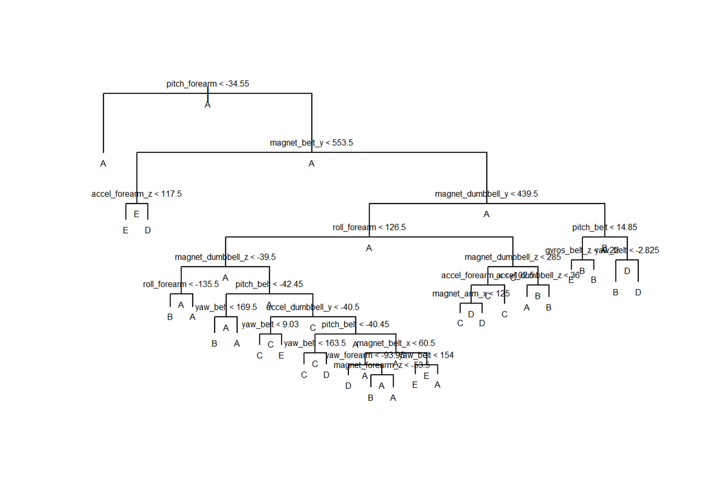

```r
plot(tree.training, asp = 1/3)
text(tree.training,pretty=0, all=TRUE,cex =.5)
```

We get a so bushy tree, and we are going to prune it to reduce number of nodes.

## 3.2 Model Fiting with Rpart

With our processed data we will fit the model with Rpart method form Caret package.

```r
library(caret, verbose=FALSE)
modFit <- train(classe ~ .,method="rpart",data=training)
print(modFit$finalModel)
```

```
## n= 13737
##
## node), split, n, loss, yval, (yprob)
##       * denotes terminal node
##
##   1) root 13737 9831 A (0.28 0.19 0.17 0.16 0.18)
##     2) pitch_forearm< -33.95 1085    8 A (0.99 0.0074 0 0 0) *
##     3) pitch_forearm>=-33.95 12652 9823 A (0.22 0.21 0.19 0.18 0.2)
##       6) magnet_belt_y>=555.5 11635 8809 A (0.24 0.23 0.21 0.18 0.15)
##        12) yaw_belt>=169.5 561   53 A (0.91 0.043 0 0.052 0) *
##        13) yaw_belt< 169.5 11074 8451 B (0.21 0.24 0.22 0.18 0.15)
##          26) magnet_dumbbell_z< -93.5 1305  531 A (0.59 0.28 0.038 0.059 0.031) *
##          27) magnet_dumbbell_z>=-93.5 9769 7422 C (0.16 0.23 0.24 0.2 0.17)
##            54) magnet_dumbbell_y< 273.5 3761 2213 C (0.2 0.14 0.41 0.13 0.12) *
##            55) magnet_dumbbell_y>=273.5 6008 4278 B (0.13 0.29 0.13 0.24 0.2)
##             110) total_accel_dumbbell>=5.5 4496 2927 B (0.089 0.35 0.17 0.16 0.23)
##               220) pitch_dumbbell>=-24.75 2046  873 B (0.034 0.57 0.028 0.11 0.25) *
##               221) pitch_dumbbell< -24.75 2450 1727 C (0.13 0.16 0.3 0.2 0.21) *
##             111) total_accel_dumbbell< 5.5 1512  763 D (0.27 0.11 0.012 0.5 0.12) *
##       7) magnet_belt_y< 555.5 1017  197 E (0.0029 0.0029 0 0.19 0.81) *
```

ploting the fitted model with rattle package

```r
library(rattle, verbose=FALSE)
```

[figure not shown]

```r
fancyRpartPlot(modFit$finalModel)
```

## 3.3 Cross Validation

We are going to check the performance of the tree on the testing data by cross validation.

```r
tree.pred=predict(tree.training,testing,type="class")
predMatrix = with(testing,table(tree.pred,classe))
sum(diag(predMatrix))/sum(as.vector(predMatrix)) # error rate
```

```
## [1] 0.7264
```

```r
tree.pred=predict(modFit,testing)
predMatrix = with(testing,table(tree.pred,classe))
sum(diag(predMatrix))/sum(as.vector(predMatrix)) # error rate
```

```
## [1] 0.5405
```

## 3.4 Pruning tree

This tree was grown to full depth, and might be too variable. We now use Cross Validation to prune it.

```r
cv.training=cv.tree(tree.training,FUN=prune.misclass)
cv.training
```

```
## $size
##  [1] 25 24 23 22 21 20 17 16 13  7  5  1
##
## $dev
##  [1] 4028 4253 4253 4707 4847 5188 5236 5236 6613 6684 7304 9831
##
## $k
##  [1]  -Inf  91.0  96.0 130.0 140.0 156.0 158.7 164.0 195.3 206.7 259.5
## [12] 634.0
##
## $method
## [1] "misclass"
##
## attr(,"class")
## [1] "prune"         "tree.sequence"
```

ploting for better visualization

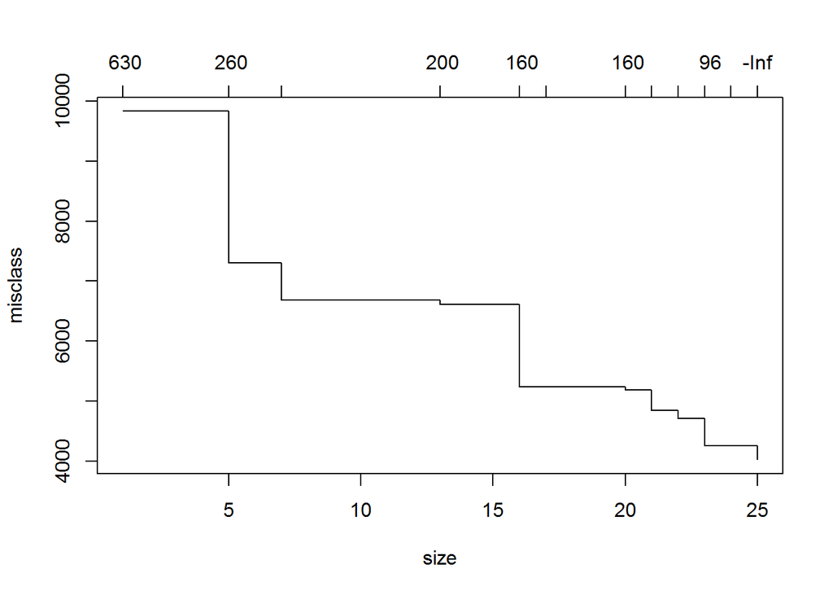

```r
plot(cv.training)
```

Suppose we prune it at size of nodes at 18.

```r
prune.training=prune.misclass(tree.training,best=18)
```

Now lets evaluate this pruned tree on the test data.

```r
tree.pred=predict(prune.training,testing,type="class")
predMatrix = with(testing,table(tree.pred,classe))
sum(diag(predMatrix))/sum(as.vector(predMatrix)) # error rate
```

```
## [1] 0.6809
```

The single tree is not good enough, so we are going to use bootstrap to improve the accuracy. We are going to try random forests.

## 3.5 Random Forests

These methods use trees as building blocks to build more complex models. Random forests build lots of bushy trees, and then average them to reduce the variance.  
Lets fit a random forest and see how well it performs.

```r
require(randomForest)
set.seed(12345)
rf.training=randomForest(classe~.,data=training,ntree=100, importance=TRUE)
rf.training
```

```
##
## Call:
##  randomForest(formula = classe ~ ., data = training, ntree = 100,      importance = TRUE)
##                Type of random forest: classification
##                      Number of trees: 100
## No. of variables tried at each split: 6
##
##         OOB estimate of  error rate: 0.7%
## Confusion matrix:
##      A    B    C    D    E class.error
## A 3902    4    0    0    0    0.001024
## B   15 2628   13    0    2    0.011287
## C    0   19 2367   10    0    0.012104
## D    0    0   21 2229    2    0.010213
## E    0    2    3    5 2515    0.003960
```

Visualizing Variables Importance

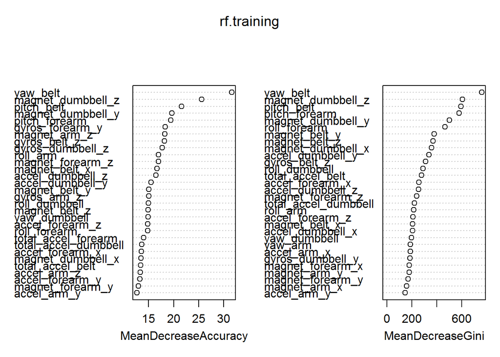

```r
varImpPlot(rf.training,)
```

we can see which variables have higher impact on the prediction.

# 4. Out-of Sample Accuracy

Our Random Forest model shows OOB estimate of error rate: 0.72% for the training data. Now we will predict it for out-of sample accuracy.  
Now lets evaluate this tree on the test data.

```r
tree.pred=predict(rf.training,testing,type="class")
predMatrix = with(testing,table(tree.pred,classe))
sum(diag(predMatrix))/sum(as.vector(predMatrix)) # error rate
```

```
## [1] 0.9946
```

0.99 means we got a very accurate estimate.  
No. of variables tried at each split: 6. It means every time we only randomly use 6 predictors to grow the tree. Since p = 43, we can have it from 1 to 43, but it seems 6 is enough to get the good result.

# 5. Conclusion

Now we can predict the testing data from the website.

```r
answers <- predict(rf.training, pml_testing)
answers
```

```
##  1  2  3  4  5  6  7  8  9 10 11 12 13 14 15 16 17 18 19 20
##  B  A  B  A  A  E  D  B  A  A  B  C  B  A  E  E  A  B  B  B
## Levels: A B C D E
```

here is the function used to generate the result files for submission.

```r
pml_write_files = function(x){
  n = length(x)
  for(i in 1:n){
    filename = paste0("Preduction_Results/", "problem_id_",i,".txt")
    write.table(x[i],file=filename,quote=FALSE,row.names=FALSE,col.names=FALSE)
  }
}
pml_write_files(answers)
```